# Hooper_ESM211_HW2_W20

Tess Hooper

2/3/2020

#### **1. Graph of *dN/dt* vs. *N***

Growth model equation: $f(N) = \frac{dN}{dt}= rN(1-\frac{N}{K}) - P(\frac{aN}{1 + ahN})$

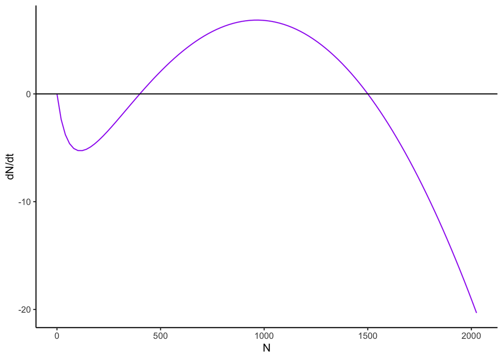

```r
### Set up parameters:

r = 0.05 # intrinsic growth
K = 2000 # carrying capacity
P = 4 # number of hunters
a = 0.05 # per prey attack rate
h = 0.2 # harvest time

f <- function(N) r*N*(1-N/K) - P*((a*N)/(1+a*h*N)) # Here is where you define the function

ggplot(data.frame(N = 0:2025), aes(x = N)) +
  stat_function(fun = "f", color = "purple") +
  geom_hline(yintercept = 0) +
  ylab("dN/dt") +
  theme_classic()
```

#### **2. Equilibria**

Based on this graph, there are three equilibria points. One at *N* = 0 (stable), *N* = ~ 400 (unstable), and *N* = 1500 (stable).

#### **3. Equilibria at *N* = 0**

**a. Is there an equilbria at *N* = 0 for all plausible parameters?**  
Yes. When *N* = 0, *dN/dt* will always be zero because of the given equation. There will always be a 0 in the first part of the equation, and then the second half of the equation will be divided by a zero

**b. For what values of hunter number (P), espressed in terms of the other parameters of the model, is the zero equilibrium stable?**

```r
deriveFn <- Deriv(f)

deriveFn
```

```
## function (N)
## {
##     .e1 <- 1 + a * h * N
##     N * (a^2 * h * P/.e1^2 - r/K) + r * (1 - N/K) - a * P/.e1
## }
```

```r
Simplify(deriveFn)
```

```
## function (N)
## {
##     .e1 <- 1 + a * h * N
##     N * (a^2 * h * P/.e1^2 - r/K) + r * (1 - N/K) - a * P/.e1
## }
```

```r
# .e1 <- 1 + a * h * N , N * (a^2 * h * P/.e1^2 - r/K) + r * (1 - N/K) - a * P/.e1
```

When *N* = 0, the equation can be rearranged to become $\frac{df(N)}{dN} = r - Pa$

$0 = r-Pa$  
$P = (\frac{r}{a})$

**c. If your goal is to eliminate the invasive species, what does this tell you about how many hunters you need?**  
If the species growth rate increases, the more hunters are needed. The number of hunters is dependent on the species growth rate and the per-prey attack rate. ($P = (\frac{r}{a})$). In order to have a stable zero equilibrium, and to eliminate the invasive species, P must be greater than $(\frac{r}{a})$.

#### 5. Intrinsic Growth Rate and Hunting Rates

Intrinsic population growth: $(rN(1-\frac{N}{K}))$  
Hunting rate: $P(\frac{aN}{1+ahN})$

**a. Using the same parameters from before, graph both the intrinsic growth rate and hunting rate functions of N on the same graph**

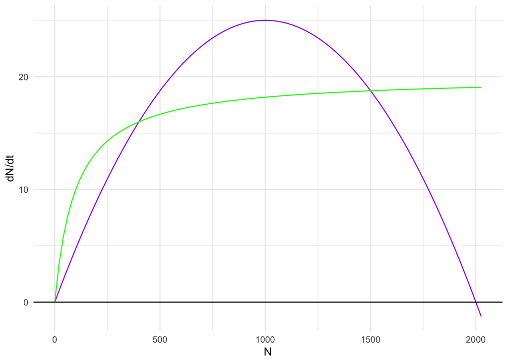

```r
r <- 0.05
K <- 2000
P <- 4
a <- 0.05
h <- 0.2

# Intrinsic Population Growth Rate Function

ipgr <- function(N) (r*N) * (1 - N/K)

# Hunting Rate Function

hr <- function(N) P* ((a* N)/(1 + a*h*N))

rates_plot <- ggplot(data.frame(N = 0:2025), aes(x=N)) +
  stat_function(fun = ipgr, color = "purple") +
  stat_function(fun = hr, color = "green") +
  geom_hline(yintercept = 0) +
  ylab("dN/dt") +
  theme_minimal()

rates_plot
```

**b. What will happen to the population when the hunting rate is greater than the growth rate? When it is less? When they are equal?**  
When the hunting rate (P) is greater than the growth rate, the invasive species will decrease (and be eliminated). If P is less than the growth rate, then the invasive species population will grow. If they are equal then the population will reamin stable.

**c. How do the patterns you see on this graph relate to the ones in Problem 1?**  
The equilibrium values on this graph are the same as in our Problem 1 graph. The equilibrium points for N will be where the hunting rate and growth rate meet: 0, ~400, 1500.

#### 6. Equilibria with different *P* values

Make two similar graphs, keeping all parameters the same but setting P = 1 in one graph and P = 6 in the other. How many equilibria are there in each case, and which are stable?

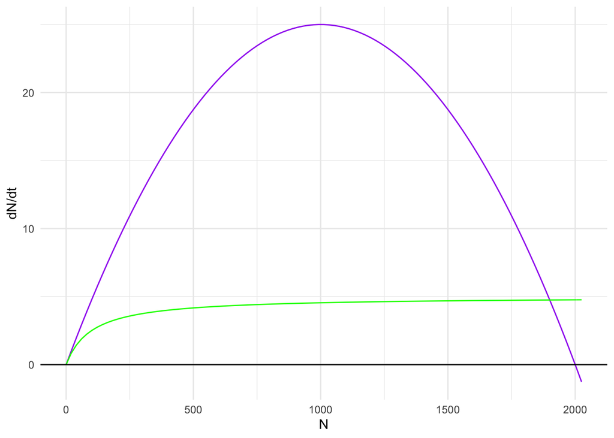

```r
### Graph when P = 1

r <- 0.05
K <- 2000
P <- 1
a <- 0.05
h <- 0.2

# Intrinsic Population Growth Rate Function

ipgr_P1 <- function(N) (r*N) * (1 - N/K)

# Hunting Rate Function

hr_P1 <- function(N) P* ((a* N)/(1 + a*h*N))

P1_plot <- ggplot(data.frame(N = 0:2025), aes(x=N)) +
  stat_function(fun = ipgr_P1, color = "purple") +
  stat_function(fun = hr_P1, color = "green") +
  geom_hline(yintercept = 0) +
  ylab("dN/dt") +
  theme_minimal()


P1_plot
```

When P = 1, there are two equilibrium points: N = 0 (unstable), and N = ~1900 (stable).

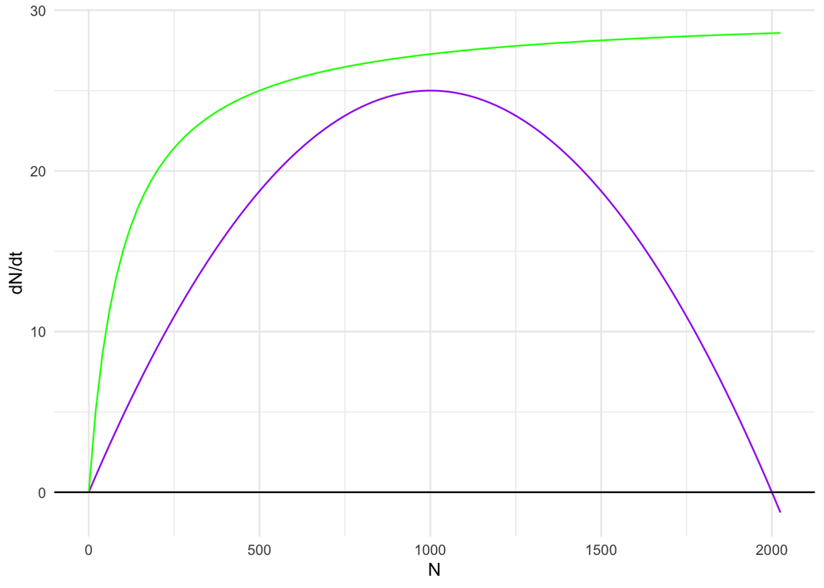

```r
### Graph when P = 6

r <- 0.05
K <- 2000
P <- 6
a <- 0.05
h <- 0.2

# Intrinsic Population Growth Rate Function

ipgr_P6 <- function(N) (r*N) * (1 - N/K)

# Hunting Rate Function

hr_P6 <- function(N) P* ((a* N)/(1 + a*h*N))

P6_plot <- ggplot(data.frame(N = 0:2025), aes(x=N)) +
  stat_function(fun = ipgr_P6, color = "purple") +
  stat_function(fun = hr_P6, color = "green") +
  geom_hline(yintercept = 0) +
  ylab("dN/dt") +
  theme_minimal()


P6_plot
```

When P = 6 there is only one equilibrium point at N = 0 and it is stable. In this case P exceeds the intrinsic growth rate after zero.

#### 7. Bistability

**a. What is the domain of attraction of the zero equilibrium (approximately - you can estimate this from the graph)? What is the domain of attraction of the largest equilibrium?**  
Looking at the initial graph of P = 4, the domain of attraction for the zero equilibrium is any value of N between 0 and ~400, where the hunting rate first crosses the growth rate. For the largest equilibrium at N = 1500, the domain of attraction is between N = ~400 and N = 2000.

**b. If you noticed the arrival of the species soon after it arrives, and initiated control activities when it had reached N = 100 individuals, would you be able to extirpate it with 4 hunters?**  
When N = 100, the hunting rate exceeds the growth rate, so we will be able to extirpate the species. Howver, at P = 1, we woud not be able to extirpate the species because the hunting rate is below the growth rate.

#### 8. Changing number of hunters

*How do the equilibrium values depend on the number of hunters?*